# ARIMA - Ristorante1

```r
# Clean Workspace
rm(list=ls())
```

## Setting & Function

```r
set.seed(100)

# Setting librerie utili
# Package names
packages <- c("readxl",  "readr", "forecast", "dplyr", "ggplot2",
              "lubridate", "KFAS", "tseries", "xts", "fastDummies")

# Install packages if not yet installed
installed_packages <- packages %in% rownames(installed.packages())
if (any(installed_packages == FALSE)) {
  install.packages(packages[!installed_packages])
}

# Packages loading
invisible(lapply(packages, library, character.only = TRUE))
# Setting working directory
working_dir = "C:/Users/marco/OneDrive/UNIMIB_DataScience/99-PROJECTS/DataScienceLab2022/Dati ristoranti"
setwd(working_dir)

# MAPE
mape <- function(actual,pred){
  mape <- mean(abs((actual - pred)/actual))*100
  return (mape)
}

#MSE
rmse <- function(actual, pred){
  rmse <- sqrt(mean((actual - pred)^2))
  return (rmse)
}

# Significatività dei parametri
pars_test <- function(coef, var_coef){
  test <- (1-pnorm(abs(coef)/sqrt(diag(var_coef))))*2
  return(test)
}

# Grafico errore percentuale
err_plot <- function(actual, pred){
  require(xts)
  err_perc <- ((actual - xts(pred, order.by = index(actual)))/(xts(actual, order.by = index(actual))))*100
  return(plot(err_perc, ylab="% errore", main="Errore percentuale di previsione"))

}
```

# Load data

```r
r1 <- read.csv(file.choose())
r1$data  <- parse_date(r1$data, "%Y-%m-%d", locale = locale("it"))
head(r1)
```

|  | X.1 | X | id_ristorante | Location | Regione | Provincia | data | scontrini | lordototale | Prezzo_medio_per_scontrino | Giorno | Month | Year | Season | Weekend | Festivo | Popolazione | Precipitazioni.mm. | Pioggia | ColoreCOVID | Dose1 | Dose2 | DoseUnica | Booster1 | Booster3Dosi | Booster2 | Dose1Cum | Dose2Cum | DoseUnicaCum | … |
| --- | --- | --- | --- | --- | --- | --- | --- | --- | --- | --- | --- | --- | --- | --- | --- | --- | --- | --- | --- | --- | --- | --- | --- | --- | --- | --- | --- | --- | --- | --- |
| 1 | 1 | 245 | R000 | Montebello | Lombardia | Pavia | 2018-09-03 | 657 | 16201.27 | 24.65947 | Monday | 9 | 2018 | Summer | False | False | 1596 | NA |  | NA | NA | NA | NA | NA | NA | NA | NA | NA | NA | … |
| 2 | 2 | 246 | R000 | Montebello | Lombardia | Pavia | 2018-09-04 | 647 | 16409.71 | 25.36277 | Tuesday | 9 | 2018 | Summer | False | False | 1596 | NA |  | NA | NA | NA | NA | NA | NA | NA | NA | NA | NA | … |
| 3 | 3 | 247 | R000 | Montebello | Lombardia | Pavia | 2018-09-05 | 635 | 15374.10 | 24.21118 | Wednesday | 9 | 2018 | Summer | False | False | 1596 | NA |  | NA | NA | NA | NA | NA | NA | NA | NA | NA | NA | … |
| 4 | 4 | 248 | R000 | Montebello | Lombardia | Pavia | 2018-09-06 | 652 | 16531.07 | 25.35441 | Thursday | 9 | 2018 | Summer | False | False | 1596 | 19.8 | True | NA | NA | NA | NA | NA | NA | NA | NA | NA | NA | … |
| 5 | 5 | 249 | R000 | Montebello | Lombardia | Pavia | 2018-09-07 | 886 | 22057.70 | 24.89583 | Friday | 9 | 2018 | Summer | True | False | 1596 | NA |  | NA | NA | NA | NA | NA | NA | NA | NA | NA | NA | … |
| 6 | 6 | 250 | R000 | Montebello | Lombardia | Pavia | 2018-09-08 | 1097 | 28190.46 | 25.69777 | Saturday | 9 | 2018 | Summer | True | False | 1596 | NA |  | NA | NA | NA | NA | NA | NA | NA | NA | NA | NA | … |

## Data preparation

```r
# ts vendite
vendite_r1 <- r1[, c(7,9)]
head(vendite_r1)
```

|  | data | lordototale |
| --- | --- | --- |
| 1 | 2018-09-03 | 16201.27 |
| 2 | 2018-09-04 | 16409.71 |
| 3 | 2018-09-05 | 15374.10 |
| 4 | 2018-09-06 | 16531.07 |
| 5 | 2018-09-07 | 22057.70 |
| 6 | 2018-09-08 | 28190.46 |

```r
str(vendite_r1)
```

```
## 'data.frame':    539 obs. of  2 variables:
##  $ data       : Date, format: "2018-09-03" "2018-09-04" ...
##  $ lordototale: num  16201 16410 15374 16531 22058 ...
```

```r
# Trasformo ts in oggetto xts
vendite_r1 <- as.xts(vendite_r1[,-1], order.by = vendite_r1[,1])
head(vendite_r1)
```

```
##                [,1]
## 2018-09-03 16201.27
## 2018-09-04 16409.71
## 2018-09-05 15374.10
## 2018-09-06 16531.07
## 2018-09-07 22057.70
## 2018-09-08 28190.46
```

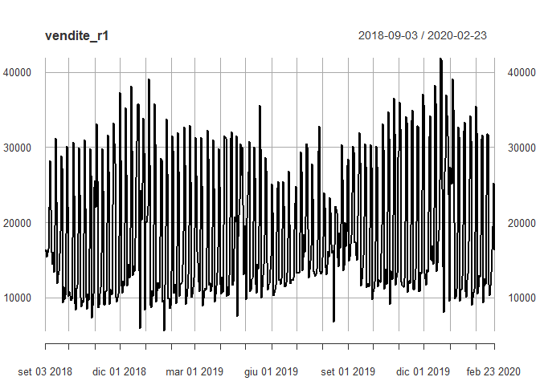

```r
plot(vendite_r1)
```

## Stagionalità

Confrontiamo la media degli incassi dei giorni feriali (non festivi) rispetto alla media del weekend (considero weekend Venerdì-Sabato-Domenica)

```r
# Media dei giorni feriali

feriali <- r1[r1$Weekend == 'False',c("data", "lordototale", "Giorno", "Festivo")]
feriali <- feriali[feriali$Festivo == "False",]
tapply(feriali$lordototale, feriali$Giorno, mean)
```

```
##    Monday  Thursday   Tuesday Wednesday
##  11962.47  13520.99  12033.96  13089.51
```

```r
# Media dei giorni "weekend"
weekend <- r1[r1$Weekend == 'True',c("data", "lordototale", "Giorno", "Festivo")]
# weekend <- weekend[weekend$Festivo == "False",]
tapply(weekend$lordototale, weekend$Giorno, mean)
```

```
##   Friday Saturday   Sunday
## 19922.83 31510.69 27733.93
```

```r
# Confronto media giorni lun-gio in base a se è festivo o meno
festivo_noweekend <- r1[r1$Weekend == 'False',c("data", "lordototale", "Giorno", "Festivo")]
tapply(festivo_noweekend$lordototale, festivo_noweekend$Festivo, mean)
```

```
##    False     True
## 12639.92 19018.46
```

```r
# Costruzione dummy per modellare stagionalità a 7 giorni

require('fastDummies')
dum_day <- r1[, c("data", "Giorno")]
dum_day[,"Giorno"] <- as.factor(dum_day$Giorno)
dum_day <- dummy_cols(dum_day, select_columns = c("Giorno"),
                      remove_first_dummy = TRUE,
                      remove_selected_columns = TRUE)
dum_day
```

| data | Giorno_Monday | Giorno_Saturday | Giorno_Sunday | Giorno_Thursday | Giorno_Tuesday | Giorno_Wednesday |
| --- | --- | --- | --- | --- | --- | --- |
| 2018-09-03 | 1 | 0 | 0 | 0 | 0 | 0 |
| 2018-09-04 | 0 | 0 | 0 | 0 | 1 | 0 |
| 2018-09-05 | 0 | 0 | 0 | 0 | 0 | 1 |
| 2018-09-06 | 0 | 0 | 0 | 1 | 0 | 0 |
| 2018-09-07 | 0 | 0 | 0 | 0 | 0 | 0 |
| 2018-09-08 | 0 | 1 | 0 | 0 | 0 | 0 |
| 2018-09-09 | 0 | 0 | 1 | 0 | 0 | 0 |
| 2018-09-10 | 1 | 0 | 0 | 0 | 0 | 0 |
| 2018-09-11 | 0 | 0 | 0 | 0 | 1 | 0 |
| 2018-09-12 | 0 | 0 | 0 | 0 | 0 | 1 |

[output cut: 529 more lines]

```r
# Costruzione dummuy per weekend e festivi
dum_week <- r1[, c("data","Weekend", "Festivo")]
dum_week[, "Festivo"] <- as.factor(dum_week$Festivo)
dum_week[, "Weekend"] <- as.factor(dum_week$Weekend)
dum_week <- dummy_cols(dum_week, select_columns = c("Weekend", "Festivo"),
                       remove_first_dummy = TRUE,
                       remove_selected_columns = TRUE)
dum_week
```

| data | Weekend_True | Festivo_True |
| --- | --- | --- |
| 2018-09-03 | 0 | 0 |
| 2018-09-04 | 0 | 0 |
| 2018-09-05 | 0 | 0 |
| 2018-09-06 | 0 | 0 |
| 2018-09-07 | 1 | 0 |
| 2018-09-08 | 1 | 0 |
| 2018-09-09 | 1 | 1 |
| 2018-09-10 | 0 | 0 |
| 2018-09-11 | 0 | 0 |
| 2018-09-12 | 0 | 0 |

[output cut: 529 more lines]

```r
# xts object con tutte le variabili dummy
dum <- cbind(dum_day, dum_week)
dum <- xts(dum[, -1], dum$data)
head(dum)
```

```
##            Giorno_Monday Giorno_Saturday Giorno_Sunday Giorno_Thursday
## 2018-09-03 "1"           "0"             "0"           "0"
## 2018-09-04 "0"           "0"             "0"           "0"
## 2018-09-05 "0"           "0"             "0"           "0"
## 2018-09-06 "0"           "0"             "0"           "1"
## 2018-09-07 "0"           "0"             "0"           "0"
## 2018-09-08 "0"           "1"             "0"           "0"
##            Giorno_Tuesday Giorno_Wednesday data         Weekend_True
## 2018-09-03 "0"            "0"              "2018-09-03" "0"
## 2018-09-04 "1"            "0"              "2018-09-04" "0"
## 2018-09-05 "0"            "1"              "2018-09-05" "0"
## 2018-09-06 "0"            "0"              "2018-09-06" "0"
## 2018-09-07 "0"            "0"              "2018-09-07" "1"
## 2018-09-08 "0"            "0"              "2018-09-08" "1"
##            Festivo_True
## 2018-09-03 "0"
## 2018-09-04 "0"
## 2018-09-05 "0"
## 2018-09-06 "0"
## 2018-09-07 "0"
## 2018-09-08 "0"
```

```r
df <- cbind(vendite_r1, dum)
df <- subset(df, select = -c(data))
head(df)
```

```
##            vendite_r1 Giorno_Monday Giorno_Saturday Giorno_Sunday
## 2018-09-03   16201.27             1               0             0
## 2018-09-04   16409.71             0               0             0
## 2018-09-05   15374.10             0               0             0
## 2018-09-06   16531.07             0               0             0
## 2018-09-07   22057.70             0               0             0
## 2018-09-08   28190.46             0               1             0
##            Giorno_Thursday Giorno_Tuesday Giorno_Wednesday Weekend_True
## 2018-09-03               0              0                0            0
## 2018-09-04               0              1                0            0
## 2018-09-05               0              0                1            0
## 2018-09-06               1              0                0            0
## 2018-09-07               0              0                0            1
## 2018-09-08               0              0                0            1
##            Festivo_True
## 2018-09-03            0
## 2018-09-04            0
## 2018-09-05            0
## 2018-09-06            0
## 2018-09-07            0
## 2018-09-08            0
```

Schema: - TRAINING, VALIDATION, TEST - TRAINING, TEST: 80% 20% - TRAINING, VALIDATION: 90% 10%

```r
# Divisione training-test set
train_date <- nrow(df) *0.8
train_temp <- df[1:train_date,]
test <- df[-c(1:train_date),] # Usare alla fine
```

```r
# Training - validation set
train_date_rid <- nrow(train_temp)*0.9
train <- train_temp[1:train_date_rid,]
validation <- train_temp[-c(1:train_date_rid),]
```

# Stazionarietà della serie storica

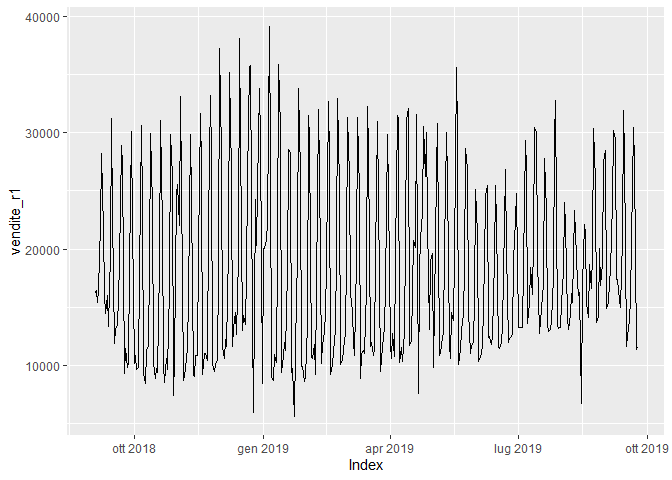

```r
# Intera serie storica
autoplot(train[,1])
```

La serie storica sembra non avere una tendenza di medio/lungo periodo a crescere o scendere (trend). Valutiamo l’andamento della funzione di autocorrelazione (totale e parziale)

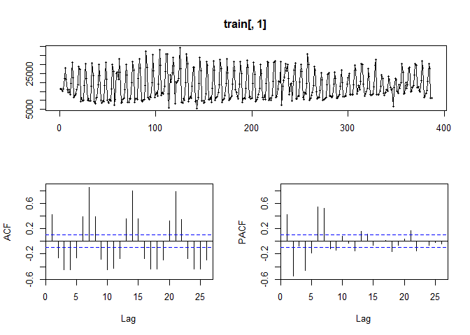

```r
tsdisplay(train[,1])
```

ACF risulta avere ritardi significativi che decadono a zero molto lentamente, sintomo di una non stazionarietà della serie storica. Notiamo come i ritardi maggiormente significativi sono quelli ai ritardi stagionali multipli di 7.

### Ljung-Box test

(a non-stationary signal will have a low p-value)

```r
lag.length = 25
Box.test(train[,1], lag=lag.length, type="Ljung-Box")
```

```
##
##  Box-Ljung test
##
## data:  train[, 1]
## X-squared = 2038.3, df = 25, p-value < 2.2e-16
```

Il test di Ljung-Box conferma l’ipotesi di non stazionarietà.

La non stazionarietà potrebbe però essere dovuta alla presenza di stagionalità nella serie storica:

```r
# Augmented Dickey–Fuller (ADF) t-statistic test for unit root
options(warn=-1)
require(tseries)

adf.test(train[,1])
```

```
##
##  Augmented Dickey-Fuller Test
##
## data:  train[, 1]
## Dickey-Fuller = -3.8715, Lag order = 7, p-value = 0.01565
## alternative hypothesis: stationary
```

Come effettivamente viene suggerito dal test di Dickey Fuller (valuta la presenza di radici unitarie)

### Differenza stagionale

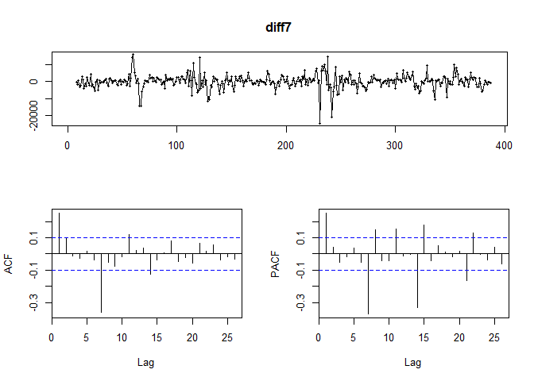

```r
diff7 <- diff(train[,1], 7)
tsdisplay(diff7)
```

```r
lag.length = 25
Box.test(diff7, lag=lag.length, type="Ljung-Box")
```

```
##
##  Box-Ljung test
##
## data:  diff7
## X-squared = 104.23, df = 25, p-value = 1.205e-11
```

## Identificazione del modello

### Modello1

- Componente AR stagionale: ACF presenta correlazione significativa al ritardo 7
- Componente MA stagionale: PACF presenta correlazioni particolarmente significative ai riatdi multipli di 7
- Componente MA non stagionale di ordine 2
- Dummy come regressori esterni
- Costante non inclusa

```r
mod1 <- Arima(y = train$vendite_r1,
              order = c(0, 0, 2),
              list(order = c(1, 0, 1), period = 7),
              xreg = train[, -1],
              include.constant = FALSE,
              )
```

#### Diagnostica:

```r
summary(mod1)
```

```
## Series: train$vendite_r1
## Regression with ARIMA(0,0,2)(1,0,1)[7] errors
##
## Coefficients:
##          ma1     ma2    sar1     sma1  Giorno_Monday  Giorno_Saturday
##       0.4021  0.1373  0.8251  -0.7018     11937.9339       10983.4949
## s.e.  0.0533  0.0525  0.1124   0.1457       708.1383         789.7186
##       Giorno_Sunday  Giorno_Thursday  Giorno_Tuesday  Giorno_Wednesday
##            2336.841       13460.8706      12130.4076        13487.4146
## s.e.       1312.462         713.8236        707.7239          712.6065
##       Weekend_True  Festivo_True
##         19386.4897     4315.3551
## s.e.      710.3426      910.9603
##
## sigma^2 = 9048973:  log likelihood = -3642.95
## AIC=7311.9   AICc=7312.87   BIC=7363.36
##
## Training set error measures:
##                     ME     RMSE      MAE       MPE    MAPE      MASE
## Training set -8.632132 2961.146 2018.489 -3.913201 13.3931 0.3372671
##                      ACF1
## Training set 0.0004195076
```

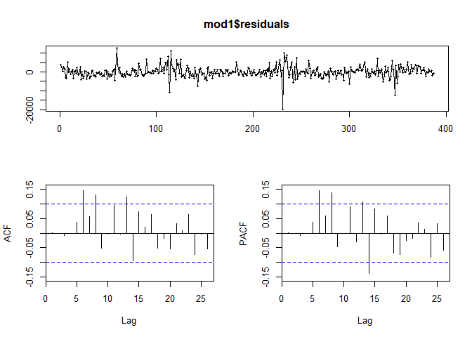

```r
tsdisplay(mod1$residuals)
```

```r
pars_test(mod1$coef, mod1$var.coef)
```

```
##              ma1              ma2             sar1             sma1
##     4.374279e-14     8.953934e-03     2.078338e-13     1.453311e-06
##    Giorno_Monday  Giorno_Saturday    Giorno_Sunday  Giorno_Thursday
##     0.000000e+00     0.000000e+00     7.499374e-02     0.000000e+00
##   Giorno_Tuesday Giorno_Wednesday     Weekend_True     Festivo_True
##     0.000000e+00     0.000000e+00     0.000000e+00     2.167452e-06
```

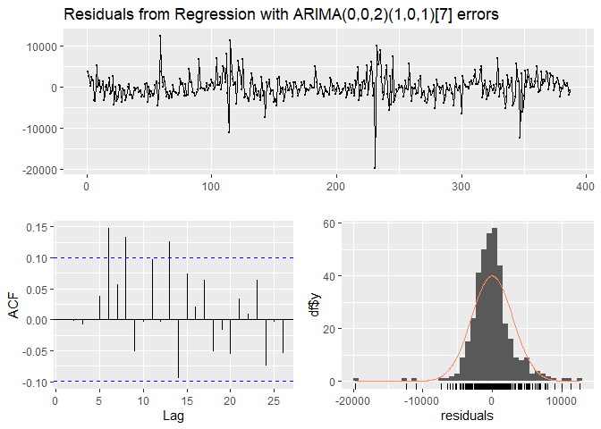

```
##
##  Ljung-Box test
##
## data:  Residuals from Regression with ARIMA(0,0,2)(1,0,1)[7] errors
## Q* = 18.46, df = 6, p-value = 0.00518
##
## Model df: 4.   Total lags used: 10
```

```r
checkresiduals(mod1)
```

```r
lag.length = 25
Box.test(mod1$residuals, lag=lag.length, type="Ljung-Box")
```

```
##
##  Box-Ljung test
##
## data:  mod1$residuals
## X-squared = 43.05, df = 25, p-value = 0.01382
```

```r
plot(train[,1],
     col = "blue", lwd=0.5,
     main = "Fitted Values")
```

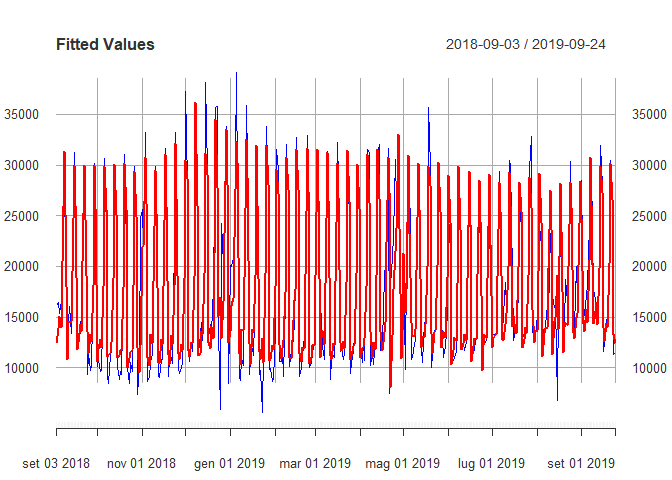

```r
lines(xts(mod1$fitted, order.by = index(train)), col="red", lwd=2.5)
```

#### Previsioni

```r
# Al momento vengono fatte previsioni 44 passi in avanti (lunghezza del validation set)
pred_mod1 <- forecast(mod1, h = 44,
                      level = 95,
                      xreg = validation[, -1])
```

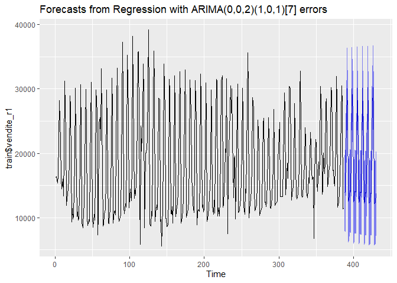

```r
autoplot(pred_mod1)
```

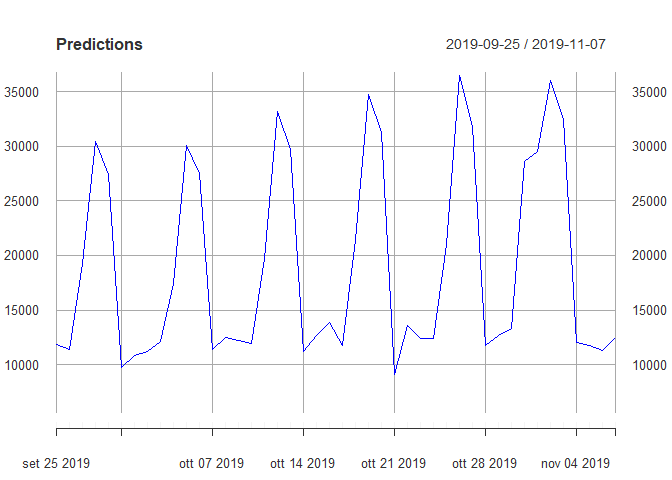

```r
plot(validation[,1],
     col = "blue", lwd=0.5,
     ylim = c(min(pred_mod1$lower), max(pred_mod1$upper)), main = "Predictions")
```

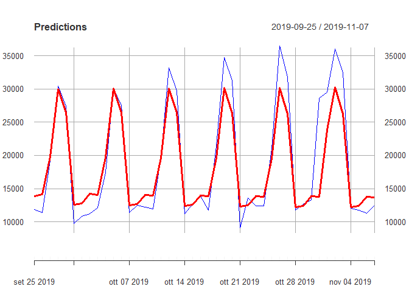

```r
lines(xts(pred_mod1$mean, order.by = index(validation)), col="red", lwd=3)
```

```r
mape(validation[,1], xts(pred_mod1$mean, order.by = index(validation)))
```

```
## [1] 12.41141
```

```r
rmse(validation[,1], xts(pred_mod1$mean, order.by = index(validation)))
```

```
## [1] 3533.433
```

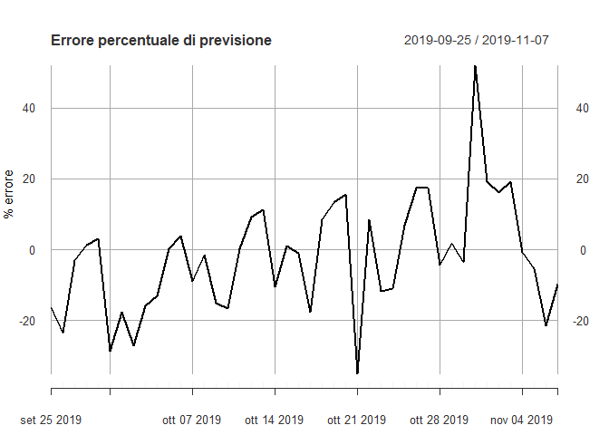

```r
err_plot(validation[,1], xts(pred_mod1$mean, order.by = index(validation)))
```

### Modello2

- Componente AR stagionale: ACF presenta correlazione significativa al ritardo 7
- Componente MA stagionale: PACF presenta correlazioni particolarmente significative ai riatdi multipli di 7
- Componente MA non stagionale di ordine 2
- Componente AR non stagionle di ordine 5
- Dummy come regressori esterni
- Costante non inclusa

```r
mod2 <- Arima(y = train$vendite_r1,
              order = c(5, 0, 2),
              list(order = c(1, 0, 1), period = 7),
              xreg = train[, -1],
              include.constant = FALSE,
              )
```

#### Diagnostica

```r
summary(mod2)
```

```
## Series: train$vendite_r1
## Regression with ARIMA(5,0,2)(1,0,1)[7] errors
##
## Coefficients:
##          ar1      ar2     ar3    ar4     ar5      ma1     ma2    sar1     sma1
##       1.4651  -0.8043  0.1290  0.037  0.0692  -1.0801  0.3457  0.8850  -0.8192
## s.e.  0.2663   0.3250  0.1393  0.101  0.0764   0.2631  0.2166  0.0609   0.0728
##       Giorno_Monday  Giorno_Saturday  Giorno_Sunday  Giorno_Thursday
##          11978.5579       10981.2192       2517.113       13501.2974
## s.e.       829.5364         753.7343       1328.660         836.1398
##       Giorno_Tuesday  Giorno_Wednesday  Weekend_True  Festivo_True
##           12173.3730        13555.1946    19405.7764      4138.118
## s.e.        828.9095          834.4577      833.0176       907.676
##
## sigma^2 = 8812287:  log likelihood = -3635.33
## AIC=7306.66   AICc=7308.52   BIC=7377.92
##
## Training set error measures:
##                     ME     RMSE      MAE       MPE     MAPE      MASE
## Training set -20.45206 2902.617 1992.218 -3.750723 13.15856 0.3328776
##                      ACF1
## Training set -0.001549781
```

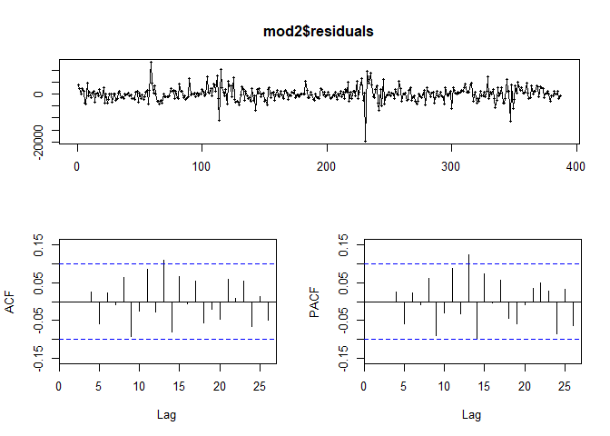

```r
tsdisplay(mod2$residuals)
```

```r
pars_test(mod2$coef, mod2$var.coef)
```

```
##              ar1              ar2              ar3              ar4
##     3.747856e-08     1.332315e-02     3.546560e-01     7.143807e-01
##              ar5              ma1              ma2             sar1
##     3.653478e-01     4.030404e-05     1.105166e-01     0.000000e+00
##             sma1    Giorno_Monday  Giorno_Saturday    Giorno_Sunday
##     0.000000e+00     0.000000e+00     0.000000e+00     5.816191e-02
##  Giorno_Thursday   Giorno_Tuesday Giorno_Wednesday     Weekend_True
##     0.000000e+00     0.000000e+00     0.000000e+00     0.000000e+00
##     Festivo_True
##     5.139158e-06
```

```r
lag.length = 25
Box.test(mod2$residuals, lag=lag.length, type="Ljung-Box")
```

```
##
##  Box-Ljung test
##
## data:  mod2$residuals
## X-squared = 27.931, df = 25, p-value = 0.311
```

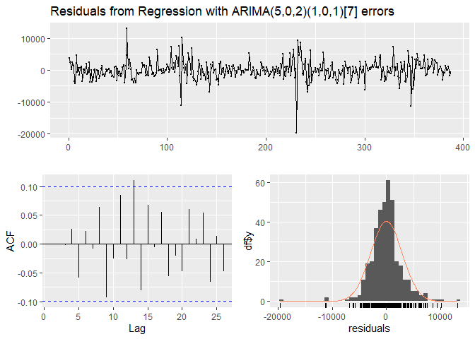

```
##
##  Ljung-Box test
##
## data:  Residuals from Regression with ARIMA(5,0,2)(1,0,1)[7] errors
## Q* = 10.3, df = 3, p-value = 0.01618
##
## Model df: 9.   Total lags used: 12
```

```r
checkresiduals(mod2)
```

```r
plot(train[,1],
     col = "blue", lwd=0.5,
     main = "Fitted Values")
```

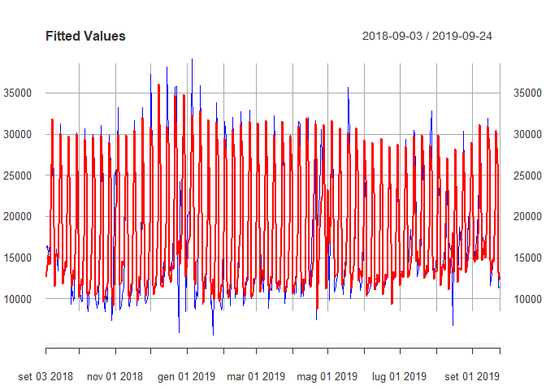

```r
lines(xts(mod2$fitted, order.by = index(train)), col="red", lwd=2.5)
```

#### Previsioni

```r
# Al momento vengono fatte previsioni 44 passi in avanti (lunghezza del validation set)
pred_mod2 <- forecast(mod2, h = 44,
                      level = 95,
                      xreg = validation[, -1])
```

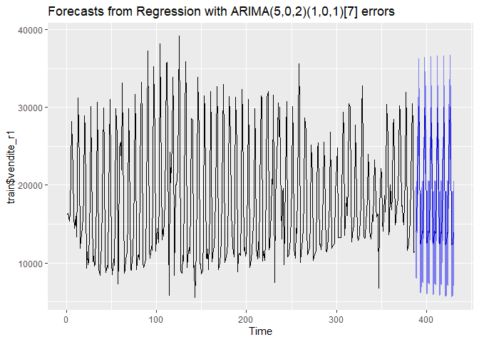

```r
autoplot(pred_mod2)
```

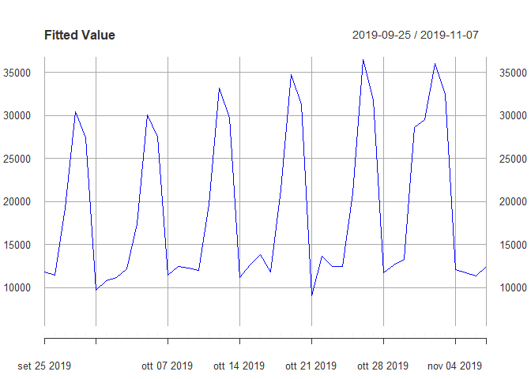

```r
plot(validation[,1],
     col = "blue", lwd=0.5,
     ylim = c(min(pred_mod2$lower), max(pred_mod2$upper)), main = "Fitted Value")
```

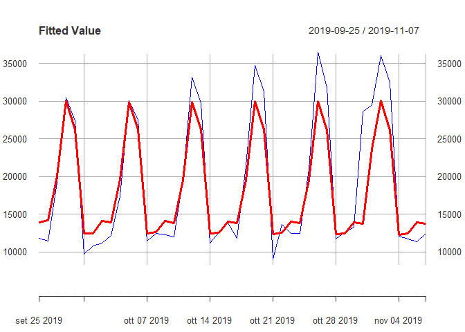

```r
lines(xts(pred_mod2$mean, order.by = index(validation)), col="red", lwd=3)
```

```r
mape(validation[,1], xts(pred_mod2$mean, order.by = index(validation)))
```

```
## [1] 12.68
```

```r
rmse(validation[,1], xts(pred_mod2$mean, order.by = index(validation)))
```

```
## [1] 3580.68
```

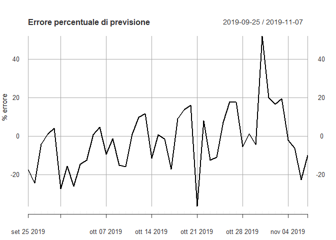

```r
err_plot(validation[,1], xts(pred_mod2$mean, order.by = index(validation)))
```

### Modello3

- Componente AR stagionale: ACF presenta correlazione significativa al ritardo 7
- Componente MA stagionale: PACF presenta correlazioni particolarmente significative ai riatdi multipli di 7
- Componente MA non stagionale di ordine 2
- Componente AR non stagionale di ordine 3
- Dummy come regressori esterni
- Costante non inclusa

```r
mod3 <- Arima(y = train$vendite_r1,
              order = c(3, 0, 2),
              list(order = c(1, 0, 1), period = 7),
              xreg = train[, -1],
              include.constant = FALSE,
              )
```

#### Diagnostica

```r
summary(mod3)
```

```
## Series: train$vendite_r1
## Regression with ARIMA(3,0,2)(1,0,1)[7] errors
##
## Coefficients:
##          ar1      ar2     ar3      ma1     ma2     sar1    sma1  Giorno_Monday
##       1.8019  -1.5270  0.4345  -1.3920  0.8837  -0.4585  0.5831     11848.3683
## s.e.  0.0871   0.0927  0.0497   0.0888  0.0712   0.2257  0.2009       550.9851
##       Giorno_Saturday  Giorno_Sunday  Giorno_Thursday  Giorno_Tuesday
##            11092.2149       2356.499       13370.1648      12048.7629
## s.e.         567.2572       1173.876         559.5065        551.5205
##       Giorno_Wednesday  Weekend_True  Festivo_True
##             13410.6953    19311.2899     4411.3156
## s.e.          555.6117      555.5811      892.9927
##
## sigma^2 = 8878296:  log likelihood = -3637.72
## AIC=7307.45   AICc=7308.92   BIC=7370.78
##
## Training set error measures:
##                     ME     RMSE      MAE       MPE  MAPE      MASE       ACF1
## Training set -7.516656 2921.331 2015.195 -3.680066 13.27 0.3367168 -0.0109813
```

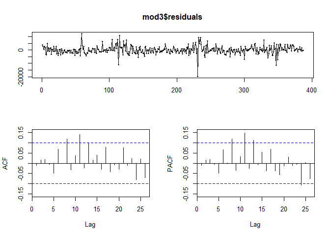

```r
tsdisplay(mod3$residuals)
```

```r
pars_test(mod3$coef, mod3$var.coef)
```

```
##              ar1              ar2              ar3              ma1
##     0.000000e+00     0.000000e+00     0.000000e+00     0.000000e+00
##              ma2             sar1             sma1    Giorno_Monday
##     0.000000e+00     4.223013e-02     3.701478e-03     0.000000e+00
##  Giorno_Saturday    Giorno_Sunday  Giorno_Thursday   Giorno_Tuesday
##     0.000000e+00     4.470156e-02     0.000000e+00     0.000000e+00
## Giorno_Wednesday     Weekend_True     Festivo_True
##     0.000000e+00     0.000000e+00     7.815335e-07
```

```r
lag.length = 25
Box.test(mod3$residuals, lag=lag.length, type="Ljung-Box")
```

```
##
##  Box-Ljung test
##
## data:  mod3$residuals
## X-squared = 32.413, df = 25, p-value = 0.1464
```

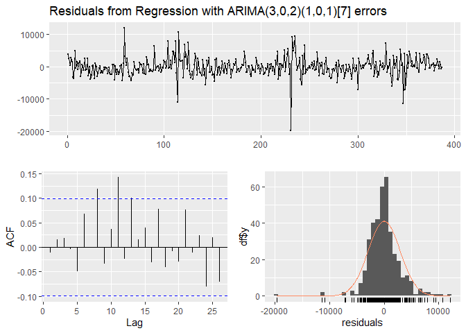

```
##
##  Ljung-Box test
##
## data:  Residuals from Regression with ARIMA(3,0,2)(1,0,1)[7] errors
## Q* = 9.7111, df = 3, p-value = 0.02119
##
## Model df: 7.   Total lags used: 10
```

```r
checkresiduals(mod3)
```

```r
plot(train[,1],
     col = "blue", lwd=0.5,
     main = "Fitted Values")
```

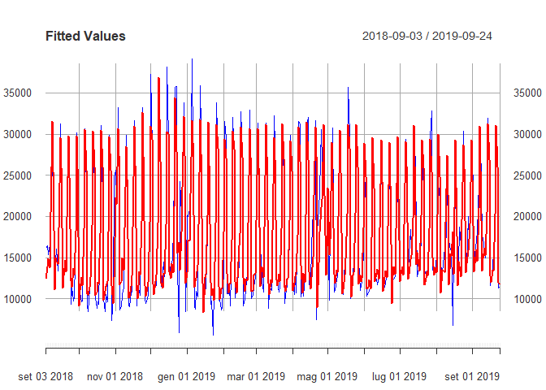

```r
lines(xts(mod3$fitted, order.by = index(train)), col="red", lwd=2.5)
```

#### Previsioni

```r
# Al momento vengono fatte previsioni 44 passi in avanti (lunghezza del validation set)
pred_mod3 <- forecast(mod3, h = 44,
                      level = 95,
                      xreg = validation[, -1])
```

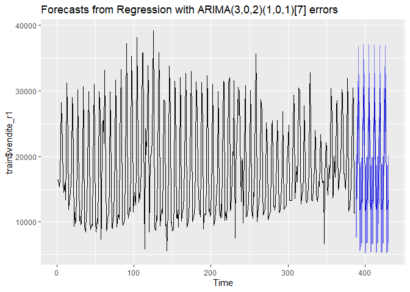

```r
autoplot(pred_mod3)
```

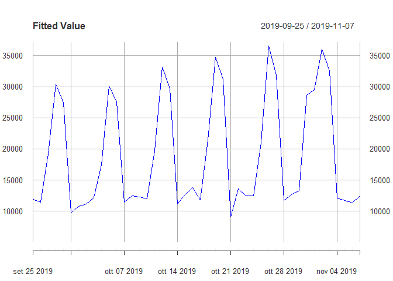

```r
plot(validation[,1],
     col = "blue", lwd=0.5,
     ylim = c(min(pred_mod3$lower), max(pred_mod3$upper)), main = "Fitted Value")
```

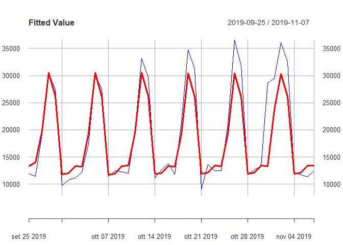

```r
lines(xts(pred_mod3$mean, order.by = index(validation)), col="red", lwd=3)
```

```r
mape(validation[,1], xts(pred_mod3$mean, order.by = index(validation)))
```

```
## [1] 10.92342
```

```r
rmse(validation[,1], xts(pred_mod3$mean, order.by = index(validation)))
```

```
## [1] 3486.209
```

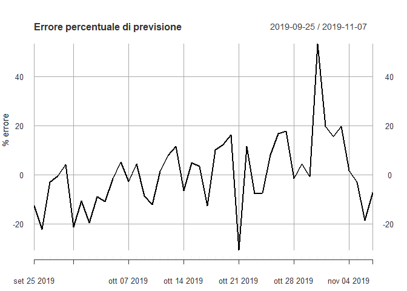

```r
err_plot(validation[,1], xts(pred_mod3$mean, order.by = index(validation)))
```

### Modello 4 SARIMAX

- Componente AR stagionale: ACF presenta correlazione significativa al ritardo 7
- Componente MA stagionale: PACF presenta correlazioni particolarmente significative ai riatdi multipli di 7
- Componente MA non stagionale di ordine 2
- Componente AR non stagionale di ordine 3
- Dummy come regressori esterni
- Vari regressori (dei regressori disponibili sono stati incluse, dopo varie prove, solamente quelli significativi)
- Costante non inclusa

```r
# xts object regressori

# Imposto a zero i giorni dove m.m. Pioggia  == 0 (Prima NaN)
r1$Precipitazioni.mm.[is.na(r1$Precipitazioni.mm.)] <- 0

# in data 23/11/2018 valore Precipitazione anomalo (-999.01) impostato a zero
r1$Precipitazioni.mm.[r1$data == "2018-11-23"] <- 0

# Manca modalità "False" per la variabile pioggia, aggiungo
r1$Pioggia[r1$Pioggia==''] <- "False"

df_reg <- df
df_reg$Precipitazioni <- r1$Precipitazioni.mm.
df_reg$Benzina <- r1$BENZINA.LITRO
df_reg$Benzina <- r1$GASOLIO_AUTO.LITRO
df_reg$Gpl <- r1$GPL.LITRO
df_reg$Riscaldamento <- r1$GASOLIO_RISCALDAMENTO.LITRO
```

```r
# Costruzione delle dummy, dove necessario
require(fastDummies)
dum_pioggia <- r1[, c("data", "Pioggia")]
dum_pioggia[,"Pioggia"] <- as.factor(dum_pioggia$Pioggia)
dum_pioggia <- dummy_cols(dum_pioggia, select_columns = c("Pioggia"),
                      remove_first_dummy = TRUE,
                      remove_selected_columns = TRUE)
dum_pioggia
```

| data | Pioggia_True |
| --- | --- |
| 2018-09-03 | 0 |
| 2018-09-04 | 0 |
| 2018-09-05 | 0 |
| 2018-09-06 | 1 |
| 2018-09-07 | 0 |
| 2018-09-08 | 0 |
| 2018-09-09 | 0 |
| 2018-09-10 | 0 |
| 2018-09-11 | 0 |
| 2018-09-12 | 0 |

[output cut: 529 more lines]

```r
df_reg$Pioggia_True <- dum_pioggia$Pioggia_True
```

Rifaccio la divisione trainin/validation/test set con il df_reg appena creato

```r
# Divisione training-test set
train_date <- nrow(df_reg) *0.8
train_temp <- df_reg[1:train_date,]
test_reg <- df_reg[-c(1:train_date),] # Usare alla fine
```

```r
# Training - validation set
train_date_rid <- nrow(train_temp)*0.9
train_reg <- train_temp[1:train_date_rid,]
validation_reg <- train_temp[-c(1:train_date_rid),]
```

```r
mod4 <- Arima(y = train_reg$vendite_r1,
              order = c(3, 0, 2),
              list(order = c(1, 0, 1), period = 7),
              xreg = train_reg[, -c(1,11,12,14)], # Rimosse le variabili non significative
              include.constant = FALSE,
              )
```

#### Diagnostica

```r
summary(mod4)
```

```
## Series: train_reg$vendite_r1
## Regression with ARIMA(3,0,2)(1,0,1)[7] errors
##
## Coefficients:
##          ar1      ar2     ar3      ma1     ma2    sar1     sma1  Giorno_Monday
##       0.9750  -1.0812  0.2513  -0.6072  0.8853  0.8533  -0.7437       43195.88
## s.e.  0.0919   0.0978  0.0756   0.0680  0.1161  0.0821   0.1062       13316.84
##       Giorno_Saturday  Giorno_Sunday  Giorno_Thursday  Giorno_Tuesday
##            10883.7951       2163.561         44551.06        43452.67
## s.e.         802.9921       1307.109         13305.39        13318.65
##       Giorno_Wednesday  Weekend_True  Festivo_True  Precipitazioni
##               44781.68      50695.51     4364.6305        117.4003
## s.e.          13312.52      13308.50      885.5337         35.5564
##       Riscaldamento
##           -24129.08
## s.e.       10216.29
##
## sigma^2 = 8679348:  log likelihood = -3632.43
## AIC=7300.86   AICc=7302.72   BIC=7372.11
##
## Training set error measures:
##                     ME    RMSE      MAE       MPE     MAPE      MASE
## Training set -9.126444 2880.64 1982.253 -3.764103 13.15457 0.3312125
##                     ACF1
## Training set 0.006824932
```

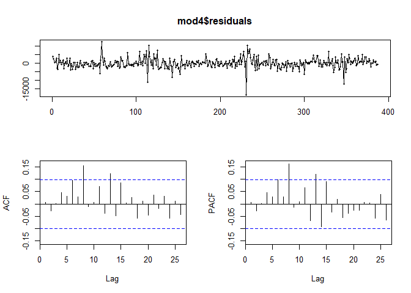

```r
tsdisplay(mod4$residuals)
```

```r
pars_test(mod4$coef, mod4$var.coef)
```

```
##              ar1              ar2              ar3              ma1
##     0.000000e+00     0.000000e+00     8.876411e-04     0.000000e+00
##              ma2             sar1             sma1    Giorno_Monday
##     2.442491e-14     0.000000e+00     2.557066e-12     1.179861e-03
##  Giorno_Saturday    Giorno_Sunday  Giorno_Thursday   Giorno_Tuesday
##     0.000000e+00     9.787857e-02     8.129521e-04     1.104175e-03
## Giorno_Wednesday     Weekend_True     Festivo_True   Precipitazioni
##     7.685599e-04     1.393851e-04     8.273051e-07     9.606508e-04
##    Riscaldamento
##     1.818522e-02
```

```r
lag.length = 25
Box.test(mod4$residuals, lag=lag.length, type="Ljung-Box")
```

```
##
##  Box-Ljung test
##
## data:  mod4$residuals
## X-squared = 33.106, df = 25, p-value = 0.1284
```

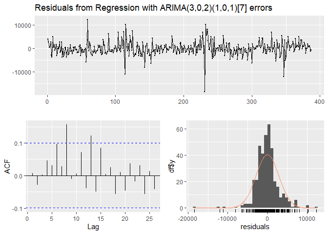

```
##
##  Ljung-Box test
##
## data:  Residuals from Regression with ARIMA(3,0,2)(1,0,1)[7] errors
## Q* = 15.354, df = 3, p-value = 0.001538
##
## Model df: 7.   Total lags used: 10
```

```r
checkresiduals(mod4)
```

```r
plot(train[,1],
     col = "blue", lwd=0.5,
     main = "Fitted Values")
```

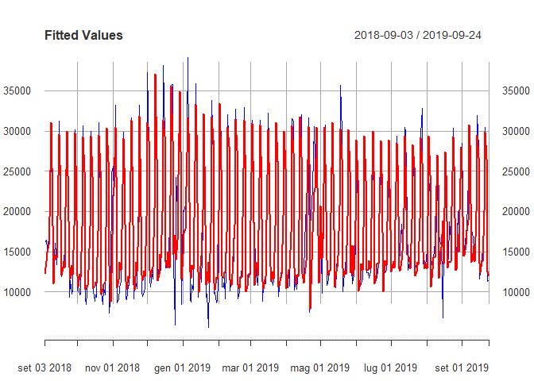

```r
lines(xts(mod4$fitted, order.by = index(train)), col="red", lwd=2.5)
```

#### Previsioni

```r
# Al momento vengono fatte previsioni 44 passi in avanti (lunghezza del validation set)
pred_mod4 <- forecast(mod4, h = 44,
                      level = 95,
                      xreg = validation_reg[, -c(1,11,12,14)])
```

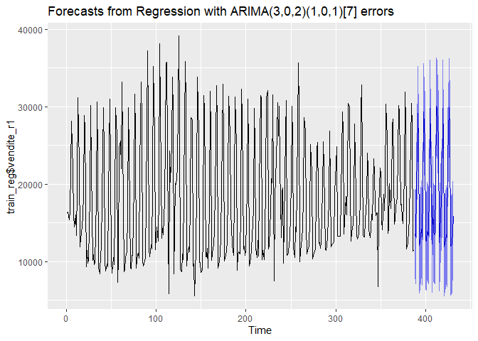

```r
autoplot(pred_mod4)
```

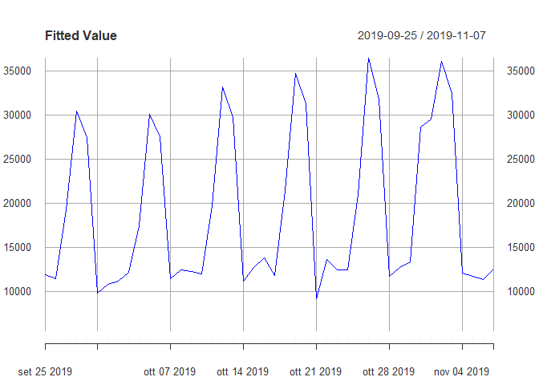

```r
plot(validation_reg[,1],
     col = "blue", lwd=0.5,
     ylim = c(min(pred_mod4$lower), max(pred_mod4$upper)), main = "Fitted Value")
```

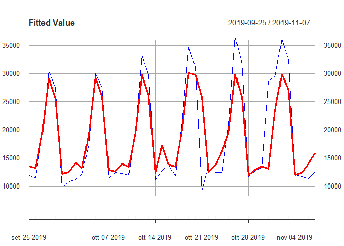

```r
lines(xts(pred_mod4$mean, order.by = index(validation_reg)), col="red", lwd=3)
```

```r
mape(validation_reg[,1], xts(pred_mod4$mean, order.by = index(validation_reg)))
```

```
## [1] 16.57827
```

```r
rmse(validation_reg[,1], xts(pred_mod4$mean, order.by = index(validation_reg)))
```

```
## [1] 4431.015
```

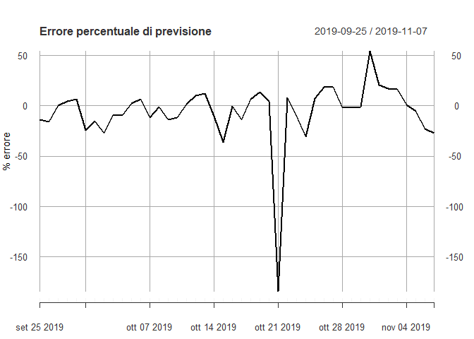

```r
err_plot(validation_reg[,1], xts(pred_mod4$mean, order.by = index(validation_reg)))
```

### Forecasting with Prophet

```r
library(prophet)
# Prophet vuole in input un df contenente data e dati storici
df_prophet <- r1[, c(7,9)]
head(df_prophet)
```

|  | data | lordototale |
| --- | --- | --- |
| 1 | 2018-09-03 | 16201.27 |
| 2 | 2018-09-04 | 16409.71 |
| 3 | 2018-09-05 | 15374.10 |
| 4 | 2018-09-06 | 16531.07 |
| 5 | 2018-09-07 | 22057.70 |
| 6 | 2018-09-08 | 28190.46 |

```r
colnames(df_prophet)[1] <- "ds"
colnames(df_prophet)[2] <- "y"
```

```r
# Divisione training-test set
train_date <- nrow(df_prophet) *0.8
train_temp <- df_prophet[1:train_date,]
test <- df_prophet[-c(1:train_date),] # Usare alla fine
```

```r
# Training - validation set
train_date_rid <- nrow(train_temp)*0.9
train <- train_temp[1:train_date_rid,]
validation <- train_temp[-c(1:train_date_rid),]
```

```r
mod_prop <- prophet(train, weekly.seasonality = TRUE)
```

```
## Disabling yearly seasonality. Run prophet with yearly.seasonality=TRUE to override this.
```

```
## Disabling daily seasonality. Run prophet with daily.seasonality=TRUE to override this.
```

```r
future <- make_future_dataframe(mod_prop, periods = 44)
```

```r
forecast <- predict(mod_prop, future)
```

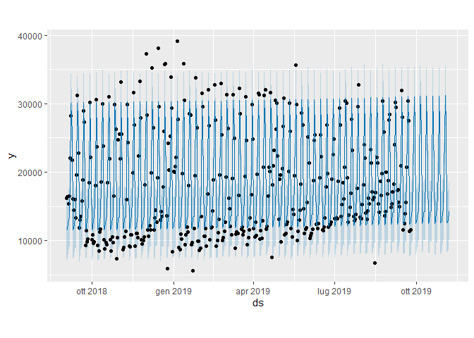

```r
plot(mod_prop, forecast)
```

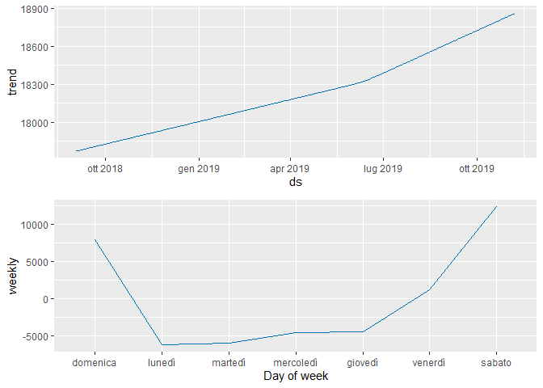

```r
prophet_plot_components(mod_prop, forecast)
```

```r
dyplot.prophet(mod_prop, forecast)
```

[interactive chart not shown]